### 7

Transform and combine the data sets so that you have five rows for each zip code (one row for each age cohort) and the following columns of data. Note that you will need to summarize the data across sex cohorts within each zip code to accomplish this task.

- `zip` = zip code
- `age` = age range
- `pop_n` = estimated # of individuals
- `obese_n` = estimated # of obese individuals
- `obese_p` = estimated proportion of obese individuals
- `rural_n` = estimated # of individuals who live in a rural household
- `urban_n` = estimated # of individuals who live in an urban household

```r
obesity7=obesity %>%
  #drop_na() %>%
  group_by(zip,age) %>%
  select(-sex) %>%
  summarise_all(sum) %>%
  mutate(pop_n=pop,
         obese_n=(obese/bmi)*pop_n,
         obese_p=obese_n/pop_n)

ru=read.csv("rural-urban.csv") %>%
  mutate(zip=clean.zipcodes(zip))

obesity7= obesity7 %>%
  left_join(ru, by="zip") %>%
  mutate(rural_n=(1-p_urban)*pop_n,
         urban_n=p_urban*pop_n) %>%
  select(zip,age,pop_n,obese_n,obese_p,rural_n,urban_n,p_urban,)

obesity7
```

```
## # A tibble: 3,870 x 8
## # Groups:   zip [774]
##    zip   age     pop_n obese_n obese_p rural_n urban_n p_urban
##    <chr> <chr>   <dbl>   <dbl>   <dbl>   <dbl>   <dbl>   <dbl>
##  1 53001 05-17     315    NA    NA         315       0       0
##  2 53001 18-34     304    79.7   0.262     304       0       0
##  3 53001 35-54     551   242.    0.439     551       0       0
##  4 53001 55-74     498   263.    0.528     498       0       0
##  5 53001 75-plus   128    NA    NA         128       0       0
##  6 53002 05-17     383    56.6   0.148     383       0       0
##  7 53002 18-34     565   152.    0.270     565       0       0
##  8 53002 35-54     765   310.    0.406     765       0       0
##  9 53002 55-74     556   273.    0.492     556       0       0
## 10 53002 75-plus   143    47.1   0.329     143       0       0
## # ... with 3,860 more rows
```

### 8

> Calculate the estimated percentage of obese individuals by age range and if they live in an urban or rural household. Display these values in a 5 by 2 table with one row for each age range and seprate columns for rural and urban.

```r
obesity7=obesity7 %>%
  mutate(ro=rural_n*obese_p,
         uo=urban_n*obese_p)%>%
  drop_na()

obesity7 %>%
  group_by(age) %>%
  summarise(rot=sum(ro),
            uot=sum(uo),
            rpop=sum(rural_n),
            upop=sum(urban_n)) %>%
  mutate(ro_rate=rot/rpop,
         uo_rate=uot/upop) %>%
  select(age,ro_rate,uo_rate)
```

```
## # A tibble: 5 x 3
##   age     ro_rate uo_rate
##   <chr>     <dbl>   <dbl>
## 1 05-17     0.174   0.157
## 2 18-34     0.325   0.301
## 3 35-54     0.486   0.449
## 4 55-74     0.501   0.457
## 5 75-plus   0.367   0.314
```

### 9

> Create a scatter plot with a point for each zip code and age range to show percentage urban on the x-axis and percentage obese on the y-axis. Use faceting to display the points in different panels of the plot for each age range. Create appropriate labels and titles for the plot. Comment on any patterns in the plot.

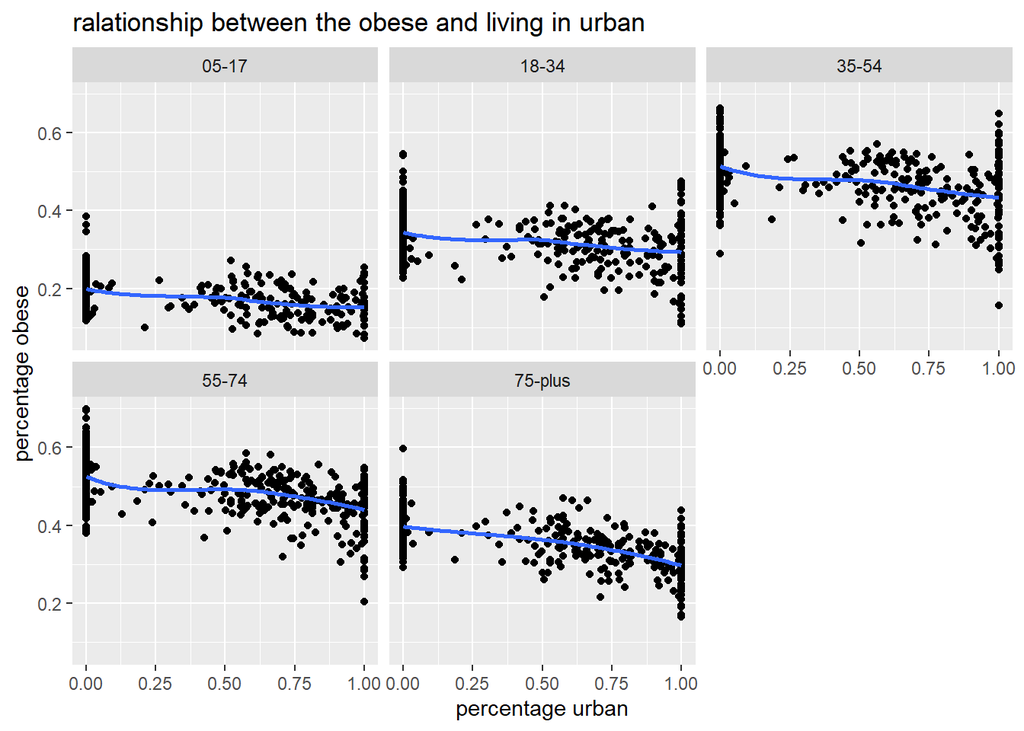

```r
obesity7 %>%
  ggplot(aes(x=p_urban,y=obese_p))+
  geom_point()+
  geom_smooth(se=FALSE)+
  facet_wrap(~age)+
  xlab("percentage urban")+
  ylab("percentage obese")+
  ggtitle("ralationship between the obese and living in urban")
```